# Investigation Overview

This is an investigation into the analysis condicted for the FordGoBikes to find the relationship between Gender, Customer, Subscriber, and how it applys to how they use the FordGoBikes.

# Trips made by Customes and Subscribers

This first pie graph shows how many customers to subscribers there are and there is obviously more subscriber then there are customers. Therfore subscribers use the bikes more often then customers.

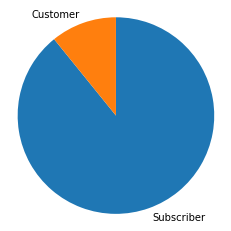

```python
#Customers to subscribers
sorted_counts = df['user_type'].value_counts()
plt.pie(sorted_counts, labels = sorted_counts.index, startangle = 90, counterclock = False);
plt.axis('square');
```

# Trips made by Customers and Subscribers

This bar graph further shows how more often then not its the Subscribers that use the bikes.

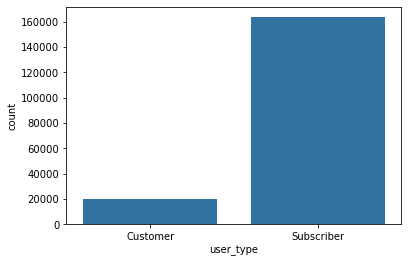

```python
# Who used the bikes more during February.
base_color = sb.color_palette()[0]
sb.countplot(data=df, x='user_type', color=base_color);
```

# Bike Usage throughout the Week

This bar graph shoes the over all use of the bikes through out the week and it shows that the majority of the rides happen during the week instead of the weekend.

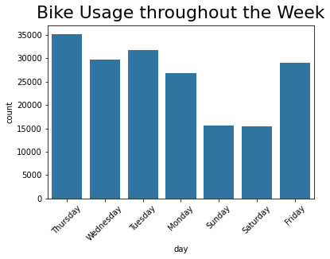

```python
#Bike usage throughout the week

base_color = sb.color_palette()[0]
sb.countplot(data=df, x='day', color=base_color);
plt.xticks(rotation = 45);
plt.title('Bike Usage throughout the Week', fontsize=22, y=1.015);
```

# Bike Usage throughout the Week

This bar graph shows the average duration of the rides during the week and it turns out that people on average take longer rides during the weekend. Since more rides happend during the weekdays it is curious to see that the longer rides happen on the weekend.

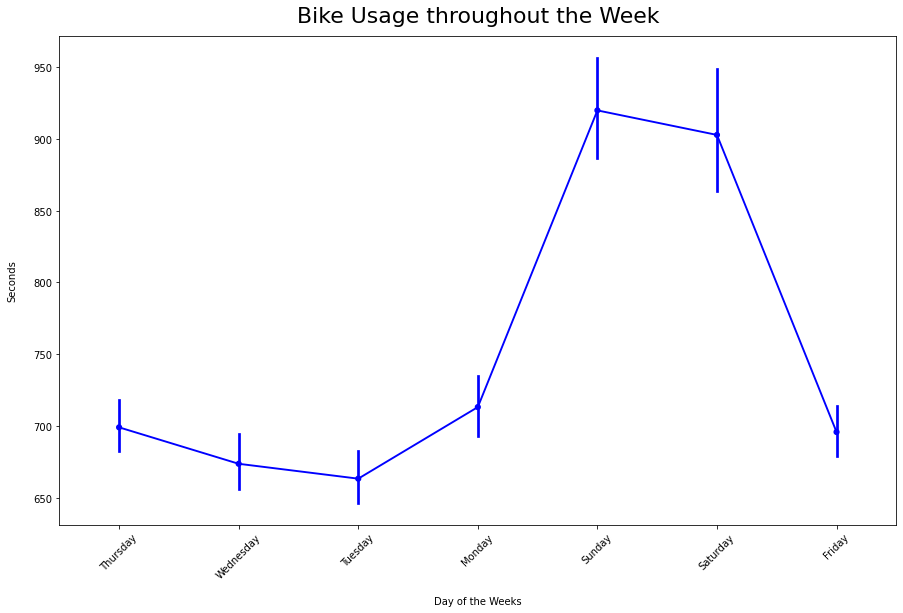

```python
plt.figure(figsize=(15,9))
sb.pointplot(data = df, x='day', y='duration_sec', scale=.7, color='blue')
plt.title('Bike Usage throughout the Week', fontsize=22, y=1.015)
plt.xlabel('Day of the Weeks', labelpad=16)
plt.ylabel('Seconds', labelpad=16)
plt.xticks(rotation = 45);
```

# Duration on Each Bike

This graph shows that on average it is the customers that take the longer bike rides. We can conclude that the customers may use them recreationally and subscibers use them for commuting.

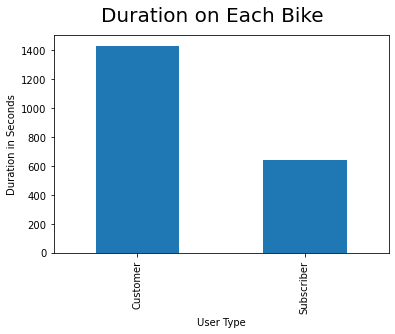

```python
#Customers tend to spend longer times on the bike then subscribers
df.groupby('user_type').duration_sec.mean().plot(kind = 'bar');
plt.ylabel('Duration in Seconds', fontsize = 10)
plt.xlabel('User Type',fontsize = 10 )
plt.suptitle('Duration on Each Bike ', fontsize = 20);
```

# Average Distances

This further shows that it is the customers that tend to travel farther then our subscribers.

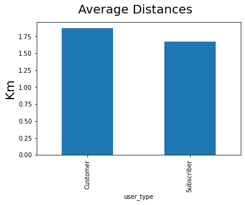

```python
#Customers on average go farther distances but there isnt a huge difference.

df.groupby('user_type').Distance.mean().plot(kind = 'bar');
plt.ylabel('Km', fontsize = 20)

plt.suptitle('Average Distances', fontsize = 20);
```

# Duration across February

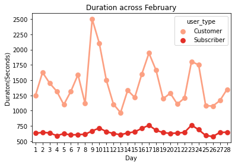

```python
# Which USER_TYPE( Customer / Subscriber) spends longer times on the bike.

sb.pointplot(data = df, x = 'Day', y = 'duration_sec', hue = 'user_type', palette = 'Reds', ci=None)
plt.title('Duration across February')
plt.ylabel('Duraton(Seconds)')
plt.xlabel('Day')
plt.show();
```

# Duartion across the Week

This graph proves the reason for there being an overall rise in bike durations during the weekend and that is because it is the customers that tend to ride the bikes on the weekend more then they do during the week.

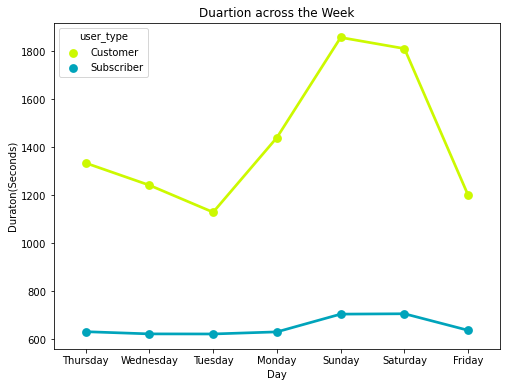

```python
#Deeper look into the TIME the user has on the bike
fig = plt.figure(figsize = [8,6])
sb.pointplot(data = df, x = 'day', y = 'duration_sec', hue = 'user_type', palette = 'nipy_spectral_r', ci=None)
plt.title('Duartion across the Week')
plt.ylabel('Duraton(Seconds)')
plt.xlabel('Day')
plt.show();
```

# Concentraton of Bike Usage

This graph proves our reason to believe that subscribers use the bikes for commuting since the heat graph shows heavy activity for the suscribers during commuting hours during the week and customers show bikes rides happening more often during the middle of the day on weekends.

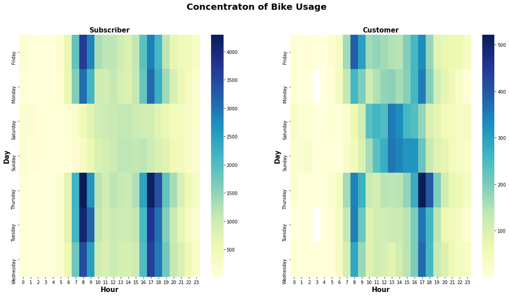

```python
#Here we can see the concentraton of BIKE USAGE during the HOURS of the WEEKDAYS.

df_sub = df.query('user_type == "Subscriber"').groupby(["day", "Hour"])["bike_id"].size().reset_index();
df_cust = df.query('user_type == "Customer"').groupby(["day", "Hour"])["bike_id"].size().reset_index();

plt.figure(figsize=(20,10));

plt.suptitle('Concentraton of Bike Usage  ', fontsize=20, fontweight='semibold')


df_sub = df_sub.pivot("day", "Hour", "bike_id");
df_cust = df_cust.pivot("day", "Hour", "bike_id");
plt.subplot(1, 2, 1);
sb.heatmap(df_sub, cmap="YlGnBu");
plt.title('Subscriber', fontweight='semibold', fontsize=15)
plt.ylabel('Day', fontweight='semibold', fontsize=15)
plt.xlabel('Hour', fontweight='semibold', fontsize=15)


plt.subplot(1, 2, 2);

sb.heatmap(df_cust, cmap="YlGnBu");
plt.title('Customer', fontweight='semibold', fontsize=15)
plt.ylabel('Day', fontweight='semibold', fontsize=15)
plt.xlabel('Hour', fontweight='semibold', fontsize=15);
```

# Gender

This graph shows the proportion of Male, Female, and other bikers. Ther are more male bikes the use FordGoBikes.

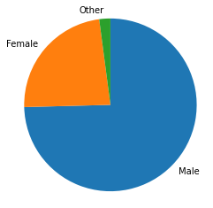

```python
# Males to Females in the data
sorted_counts = df['member_gender'].value_counts()
plt.pie(sorted_counts, labels = sorted_counts.index, startangle = 90, counterclock = False);
plt.axis('square');
```

# Time on Bike different weekdays

This graph shows that it is often women and others who spend longer times on bikes then Males do even though males use them more often.

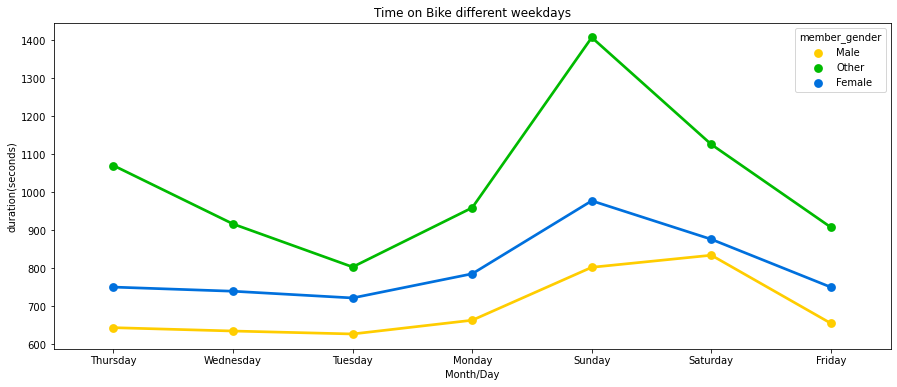

```python
#Duration across the week from different genders.
fig = plt.figure(figsize = [15,6])
sb.pointplot(data = df, x = 'day', y = 'duration_sec', hue = 'member_gender', palette = 'nipy_spectral_r', ci=None)
plt.title('Time on Bike different weekdays')
plt.ylabel('duration(seconds)')
plt.xlabel('Month/Day')
plt.show();
```

# Top Ten Start Stations

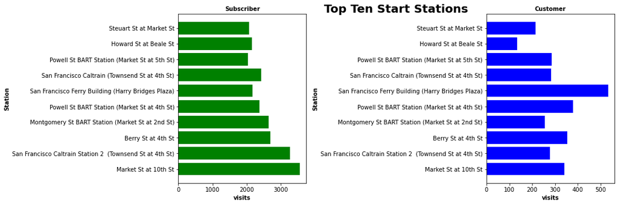

```python
# Top ten start stations by different users

df_sub = df.query('user_type == "Subscriber"').start_station_name.value_counts(ascending=True)
q = df.start_station_name.value_counts().nlargest(10)
q
q = q.index[0:10]
q = q.astype('category')



plt.figure(figsize=(15,5))

plt.subplot(1, 2, 1)
plt.barh(q,df_sub[q],color='Green',  align='center');
plt.title('Subscriber', fontweight='semibold', fontsize=10)
plt.ylabel('Station', fontweight='semibold', fontsize=10)
plt.xlabel('visits', fontweight='semibold', fontsize=10)

plt.subplot(1, 2, 2)
df_Cus = df.query('user_type == "Customer"').start_station_name.value_counts(ascending=True)
plt.barh(q,df_Cus[q],color='blue', align='center');
plt.title('Customer', fontweight='semibold', fontsize=10)
plt.ylabel('Station', fontweight='semibold', fontsize=10)
plt.xlabel('visits', fontweight='semibold', fontsize=10)

plt.suptitle('                                           Top Ten Start Stations', fontsize=20, fontweight='semibold')

plt.tight_layout()
```

# Most Common Start to End location

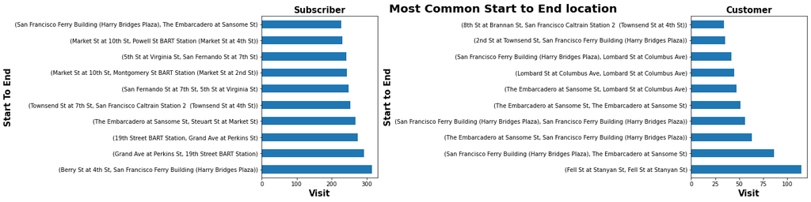

```python
# What is a Customers / Subscribers usual start and end location.

plt.figure(figsize=(20,5))

plt.suptitle('                                                 Most Common Start to End location ', fontsize=20, fontweight='semibold')

plt.subplot(1, 2, 1)
count_series = df.query('user_type == "Subscriber"').groupby(['start_station_name', 'end_station_name']).size().nlargest(10)
count_series.plot(kind = 'barh')
plt.title('Subscriber', fontweight='semibold', fontsize=15)
plt.ylabel('Start To End',fontweight='semibold', fontsize=15)
plt.xlabel('Visit',fontweight='semibold', fontsize=15)

plt.subplot(1, 2, 2)
count_se = df.query('user_type == "Customer"').groupby(['start_station_name', 'end_station_name']).size().nlargest(10)
count_se.plot(kind = 'barh')
plt.title('Customer', fontweight='semibold', fontsize=15)
plt.ylabel('Start to End', fontweight='semibold', fontsize=15)
plt.xlabel('Visit', fontweight='semibold', fontsize=15)



plt.tight_layout()
```